# FRG database/systems

September 1, 2017

## Data

## Overview

- 10 unique data sources.
- Data from 6 exchanges, 1 depository, and a microfinance institution.
- 2 proprietary databases: CMIE ProwessDX, Reuters terminal.
- Public data from websites.
- Data use contracts with 5 institutions.
- Estimate size: 50+ TB
- Organised on filesystem in around 6.5 million files.

## Data sources

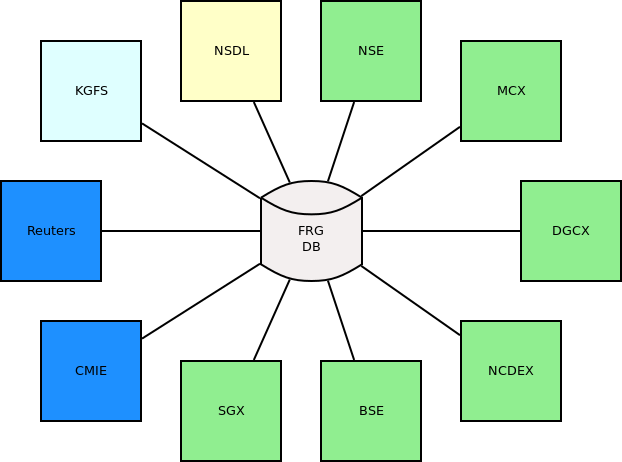

## Data from NSE

## Features

- Time period: 17 years (1999 - 2015)
- Frequency of data flow: daily (EOD)
- Frequency of transactions: tick-by-tick
- Markets: spot, futures & options on spot, and currency derivatives
- Trades and Orders (TAO)
- Market By Price (MBP)
- Limit Order Book (LOB) snapshots
- Cash index data

## Data types

- *Trades and Orders (TAO)*
- Contains all transactions happened at NSE.
- Frequency of transactions: tick-by-tick
- Transactions/second: ~60,000
- Transactions/day: ~700 million
- *Market By Price (MBP)*
- Contains order book snapshots for all stocks
- Frequency of transactions: each second
- Transactions/day: ~45 million

## Data types

- *Limit Order Book (LOB)*
- Contains order book snapshots for all stocks
- Frequency of transactions: hourly
- Records/day: ~10 million

## Data from MCX

## Features

- Time period: 5+ years
- Frequency of data flow: daily (EOD)
- Frequency of transactions: tick-by-tick
- Market: commodity futures
- Trades and Orders (TAO)
- Market By Price (MBP)
- Bhavcopy

## Data types

- *Trades and Orders*
- Contains all transactions happened at MCX.
- Frequency: tick-by-tick
- Transactions/day: ~11 million
- Span: 2013 – 2017
- *MBP*
- Limit order book of commodity futures contract 5-deep.
- Frequency: sub-second
- Span: 2012 – 2016

## Bhavcopy

- End of day position of all contracts.
- Frequency: daily
- Span: 2003 – 2017

## Data from NCDEX

## Features

- Time period: 3+ years
- Frequency of data flow: multiple
- Frequnecy of transactions: tick-by-tick
- Market: commodity futures
- Trades and Orders data
- MBP data
- Bhavcopy

## Data types

- *CASH*
- Spot prices of commodities.
- Data includes time of polling and location.
- Span: 2012 – 2015
- Frequency: twice/day
- *MBP*
- Commodity futures contracts.
- Contains limit order book, 5 deep.
- Span: 2014 – 2016

## Data types

- *Bid Ask data*
- Contains the top bid and ask values of commodity futures contracts.
- Contains OHLC values.
- Non-validated
- Span: 2012 – 2015
- Frequency: every 3-4 seconds

## Data types

- *Bid Ask live feed data*
- Contains bid and ask values of commodity futures contracts.
- Span: 2016 – 2017
- Frequency: per minute
- *Bhavcopy*
- End of day position of all contracts.
- Frequency: daily
- Span: 2006 – 2017

## Data from other exchanges

## Sources

- Thomson Reuters Eikon
- DGCX (trades and quotes): INR/USD futures
- SGX (trades and quotes): Nifty futures
- BSE public data
- NSE public data

## Data from NSDL

## Features

- Span: 2007 – 2017
- Frequency: daily
- Off-site data

### Holdings and transactions data

- Contains information for each unique client (unique) including location and category.
- Holdings data contains holding quantity of each client for a unique ISIN.
- Transactions data contains unique source and client ids for every unique ISIN.
- No direct access to database.

## Firm level database (FLD)

## Features

- Full dumps of CMIE Prowess and CMIE Capex databases.
- Contains more than 40,000 firms.
- Has 107 tables.
- Data frequency: daily, monthly, quarterly, annual
- Database: MySQL
- Size: 12GB
- Uses *SQL* to access data.

## Macro economy data (tsdb)

## Features

- Macro-economic time series data
- 20,000+ series
- 23 sources
- 200+ countries
- Data span: 15-20 years

## Software

## Database

- Flat file system.
- No binary database system.
- Can scale to any number of machines for computation.
- Use of open source software.
- Efficient and low cost.
- A metadata database to manage data.

## Application Programming Interface (API)

- IntraDay DataBase (iddb)
- Unified interface to fetch any data type or source.
- Can run programs to derive data.
- Designed to scale in terms of adding features.
- Can handle parallelism.
- Packaged in R package format to maintain discipline.

## eventstudies

- An **R** package to conduct standard event study analysis using not only daily return data but also intra-day returns data.
- A variable event window can be defined accordingly the estimation period is defined.
- Models for estimation of abnormal returns:
- Market model
- Excess returns model
- Constant mean returns model
- Augmented market model
- Inference strategies provided:
- bootstrap
- Wilcox
- Classic (t-test)

## ifrogs

A package with miscellaneous functions relating to computation of various financial measures. Currently, it has three modules:

1. DtD: Computation of distance to default.
2. pdshare: Information share.
3. vix_ci: Computation of VIX.

## Data processes

## Daily process

- Daily download
- Validation of fields
- Backup on another server
- Split files into stocks
- Backup

## Derived measures

- Impact cost
- Order matching engine
- Algorithmic trading intensity
- High frequency trading characteristics
- Tracking of orders
- Basis computation
- Active and passive orders identification
- Implied volatility

## Order matching

### The process

1. Download updated code repository.
2. Split compressed data using grep.
3. Prepare data to use with matching engine.
4. Run pre-open program.
5. Run matching engine.
6. Output trades, depth, and log files.
7. Calculate error percentages.

## Performance

- Stock: SBIN/INFY
- Depth: 10
- Segment: Cash

| Year | Number of orders | Time (core) | Time (overall) |
| --- | --- | --- | --- |
| 2009 | 65,083 | 18.74 | 74 |
| 2010 | 1,271,870 | 48.96 | 140 |
| 2011 | 3,013,716 | 105 | 276 |
| 2012 | 3,248,293 | 129.45 | 301 |
| 2013 | 5,188,148 | 178.40 | 424 |
| 2014 | 4,113,407 | 142.75 | 386 |

## Performance graph (Cash)

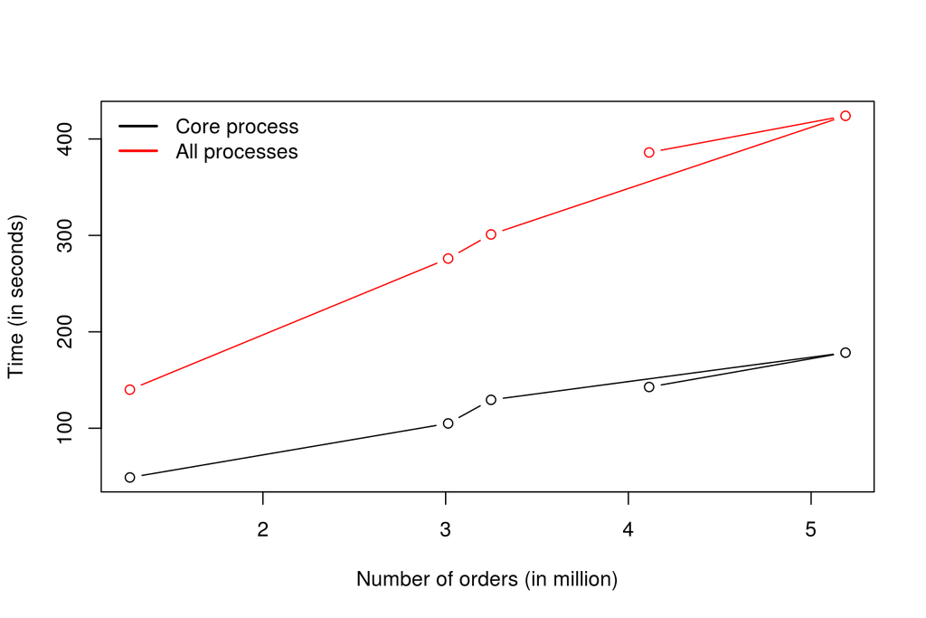

## Performance

- Stock: SBIN
- Depth: 10
- Segment: Futures & options

| Year | Number of orders | Time (core) | Time (overall) |
| --- | --- | --- | --- |
| 2009 | 722,517 | 70.29 | 124 |
| 2010 | 2,506,027 | 122.29 | 426 |
| 2011 | 4,945,747 | 311.29 | 519 |
| 2012 | 10,401,516 | 517.26 | 780 |
| 2013 | 14,288,199 | 716.56 | 1020 |
| 2014 | 16,591,150 | 1115.02 | 1620 |

## Performance graph (FAO)

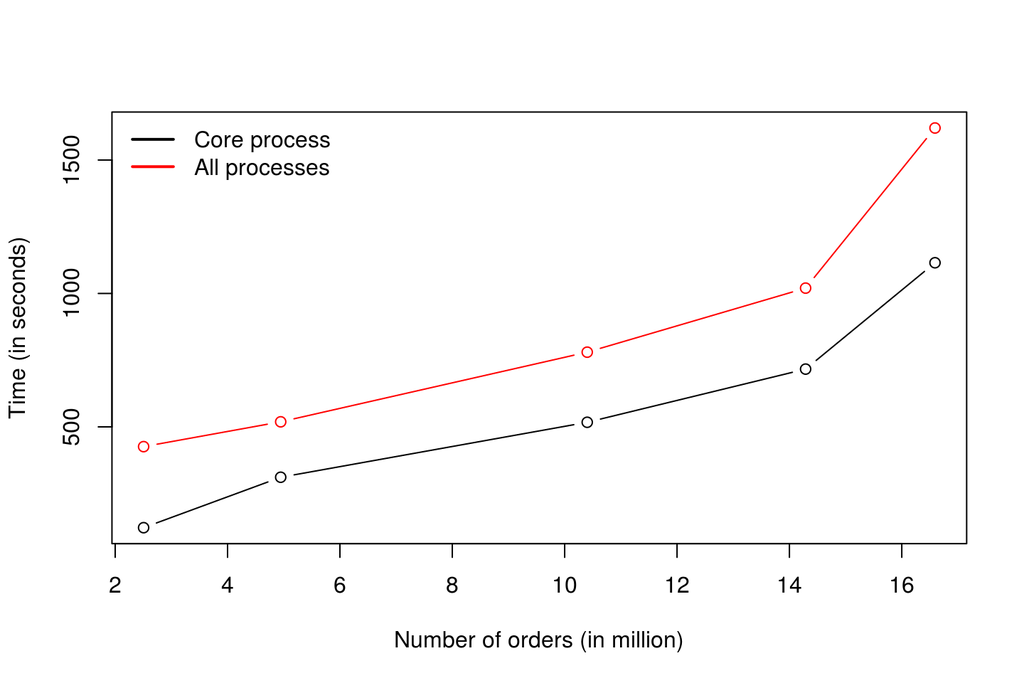

## Performance: AT Intensity

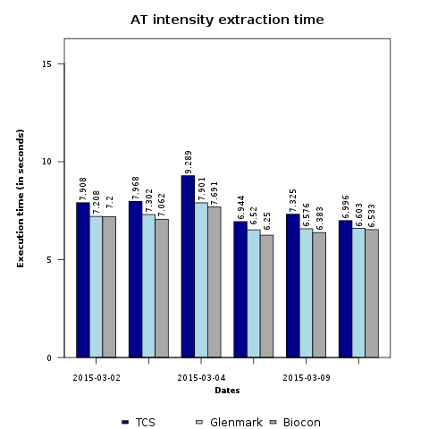

## Performance: Impact Cost

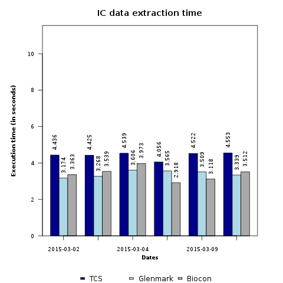

## Demo 1: Computing AT intensity

```r
d <- as.Date("2014-05-23")
system.time(
    atintensity <- iddb(dates = d,
    symbol = "INFY",
    segment = "CASH",
    measures = "atintensity",
    type = "value",
    jiffylevel = FALSE)
)
```

## Demo 2: Volatility computation using MBP data

```r
system.time(
    mbp <- iddb(dates = d,
        symbol = "INFY",
        segment = "CASH",
        measures = "mbp",
        fields =
        "ltp")
    )
vol <-function(x) {
    x <-xts::to.minutes(x, OHLC = FALSE)
    vol <- sd(x/100)
    return(vol)
    }
```

## Demo 3: MBP data from NCDEX

```r
system.time(
    comm <- iddb(dates = d,
    symbol = "CASTORSEED",
    segment = "FAO",
    measures = "mbp",
    exchange = "NCDEX",
    fields = "ltp")
    )
vol(comm[[1]])
```

## Demo 4: Generating data on the fly

```r
d <- as.Date("2014-05-27")
mbp <- iddb(dates = d,
            symbol = "3IINFOTECH",
            segment = "CASH",
            measures = "mbp",
            fields = c("bbp",
            "bsp"),
        depth = 5,
        generate = TRUE,
        wait = TRUE,
        showConsole = TRUE)
```

## Parallel computing

## Process

- Distribute workload across nodes.
- Identify tasks to run on different machines.
- Split the tasks and execute.
- Fetch or store the results.

### Strategy

- Processing on daily files.
- No dependence on previous day's results.
- Embarassingly parallel tasks.
- Scalable to N CPUs.

## Job scheduling: Jenkins (broken)

- Central system to do run tasks.
- Handles multiple nodes over SSH.
- Automatic task allocation to nodes.
- Provides HTTP API.
- Handles error notifications.
- Good replacement for cron.
- Easy management.

## Demo 5: Generating with N CPUs

```r
from <- as.Date("2014-05-22")
to <- as.Date("2014-05-28")
mbp <- iddb(from = from,
            to = to,
            symbol = "3IINFOTECH",
            segment = "CASH",
            measures = "mbp",
            exchange = "NSE",
            fields = c("bbp", "bsp", "ltp"),
            depth = 5,
            generate = TRUE,
            yield = FALSE,
            ncpu = 3)
```

## Programming

## Choice of language

- Very high performance: C
- Big data processing: C
- Statistics: R
- Data sets less than 5GB: R (data.table)
- Scripting: UNIX shell, R, and Python

## Code writing

- Code optimisations
- Use of integers wherever possible.
- Vectorised code.
- Use of 'matrix' rather than 'data.frame'.
- Knowing copy-on-write semantics of the language.

## Hardware

## System design

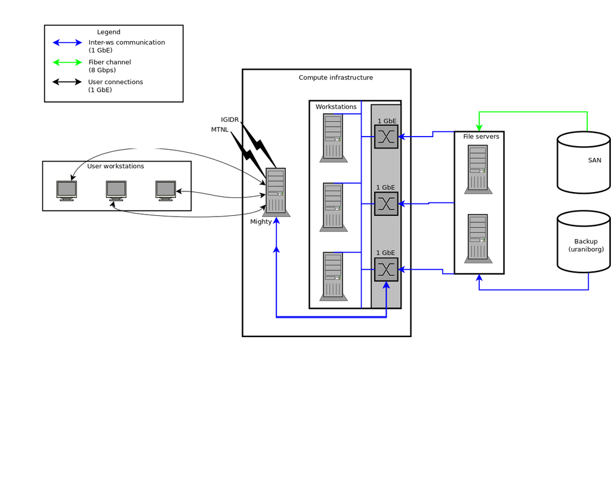

## Configuration

- Mother server: 24 cores, 128GB RAM, 33TB
- Workstations: 4 cores, 32GB RAM, 120GB SSD
- File servers: 4 cores, 32GB RAM, 120GB SSD
- Ethernet switch: 1Gbps
- OS: Arch Linux

### Storage Area Network:

- Storage: 36TB
- Connectivity: 8Gbps Fiber channel
- 2 load balancing/fail-over nodes
- Supports power failure in a single node

## Hardware

### Total capacity

- 48 CPU cores
- 24 x Intel Core i7-3770 @3.4GHz
- 24 x AMD Opteron 6172 @2.1 GHz
- Total memory: 320GB
- Storage: 99TB

### Performance

- ~300 GFLOP/S
- Linpack benchmark done using matrix of size \(68000\).

## Future design

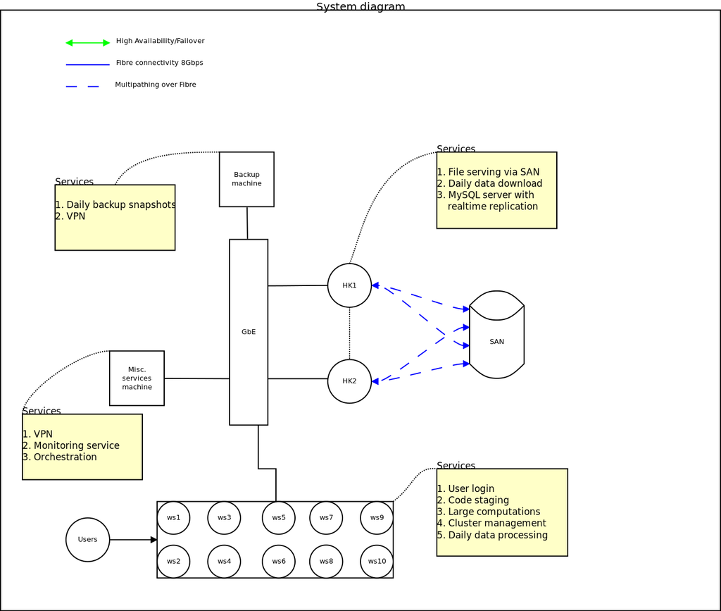

## Total capacity

- 88 CPU cores
- 64 x Intel Core i7-3770 @3.4GHz
- 24 x AMD Opteron 6172 @2.1 GHz
- Total memory: 640GB
- Storage: 136TB